# DTSA5301

M.Walton

2024-07-24

# Data Cleaning

# Analysis and Results

Alright, now that the data is neat, let’s take a look at what it’s doing. The two graphs we will see are going to show the COVID-19 case and death counts over time for the US and globally, respectively.

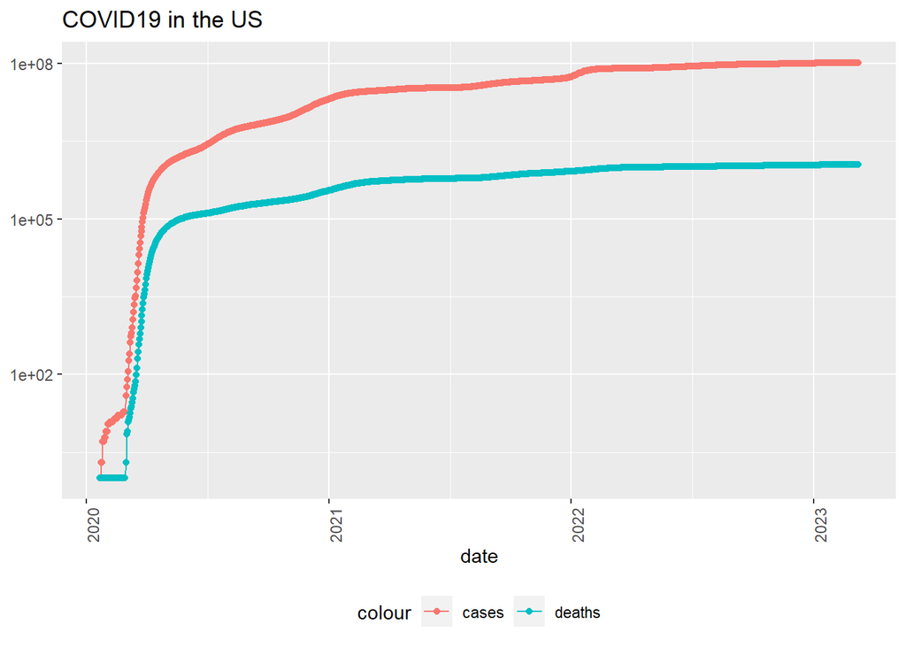

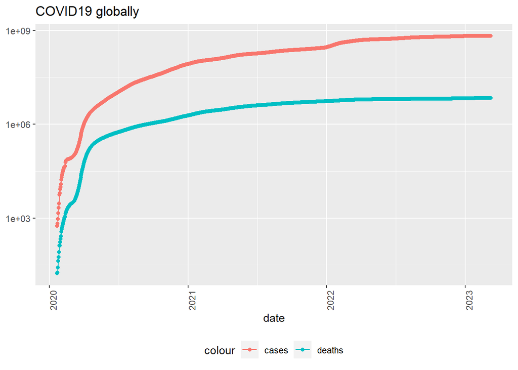

Now we are going to do some modelling. We will focus in on the US for this part. We want to see if the number of cases correlates to the number of deaths, so we will put these variables into a linear model. We should expect to see a clear positive linear relationship between cases and deaths. It’s important to know what we expect before modelling, so we can investigate if the model is not performing as expected. I will attach a summary of the model and a graph of the predictions vs actual data below.

```
##
## Call:
## lm(formula = deaths_per_though ~ cases_per_thou, data = US_by_state_totals)
##
## Residuals:
##     Min      1Q  Median      3Q     Max
## -2.3352 -0.5978  0.1491  0.6535  1.2086
##
## Coefficients:
##                Estimate Std. Error t value Pr(>|t|)
## (Intercept)    -0.36167    0.72480  -0.499     0.62
## cases_per_thou  0.01133    0.00232   4.881 9.76e-06 ***
## ---
## Signif. codes:  0 '***' 0.001 '**' 0.01 '*' 0.05 '.' 0.1 ' ' 1
##
## Residual standard error: 0.8615 on 54 degrees of freedom
## Multiple R-squared:  0.3061, Adjusted R-squared:  0.2933
## F-statistic: 23.82 on 1 and 54 DF,  p-value: 9.763e-06
```

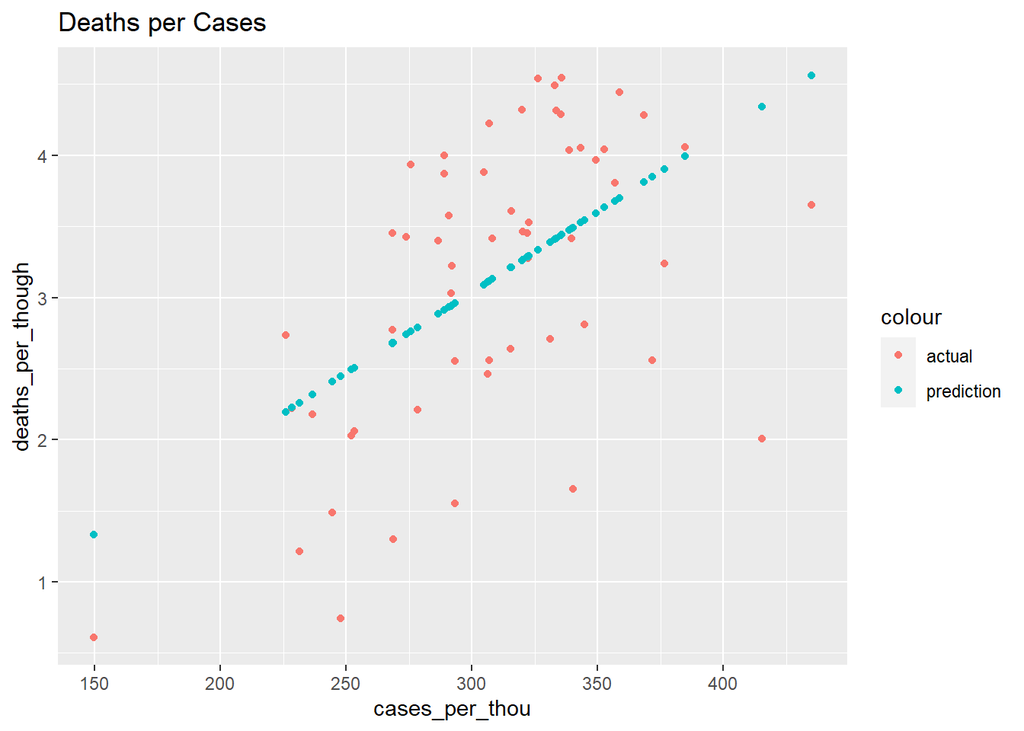

The model performs as expected with a very good p-value. We see a positive linear relationship between cases per thousand and deaths per thousand. There is high variance, but this is expected with real world data.

I live in Virginia, and lived here during COVID, so for my next analysis, I want to look specifically at Virginia. I would like to compare the counts of cases and deaths with the vaccination counts in Virginia. I want to answer the question “As vaccination increased, did the number of cases decrease?”.If we believe that vaccines stop the spread, this better be true. So I will look to prove that with a linear model. But first, let’s visualize our vaccinations as a function of time.

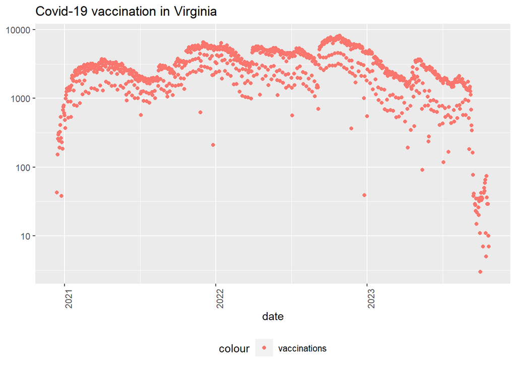

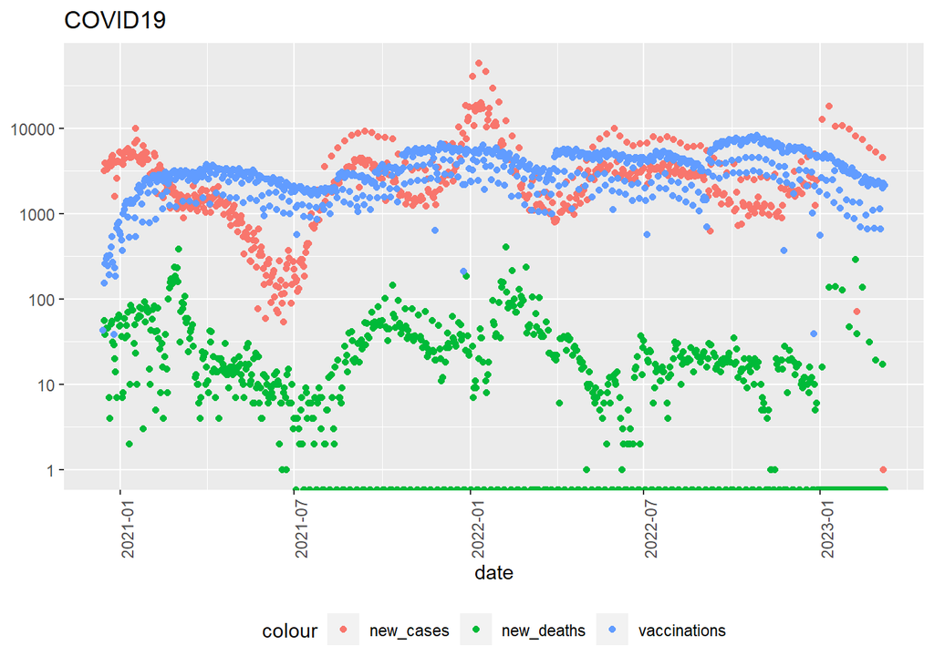

```
##
## Call:
## lm(formula = new_cases ~ vaccinations_sums, data = virginia_totals_vaccination)
##
## Residuals:
##    Min     1Q Median     3Q    Max
##  -2974  -2112  -1113    735  55186
##
## Coefficients:
##                     Estimate Std. Error t value Pr(>|t|)
## (Intercept)        2.896e+03  2.570e+02  11.266   <2e-16 ***
## vaccinations_sums -3.639e-04  1.760e-04  -2.068    0.039 *
## ---
## Signif. codes:  0 '***' 0.001 '**' 0.01 '*' 0.05 '.' 0.1 ' ' 1
##
## Residual standard error: 4247 on 813 degrees of freedom
## Multiple R-squared:  0.005231,   Adjusted R-squared:  0.004008
## F-statistic: 4.275 on 1 and 813 DF,  p-value: 0.03899
```

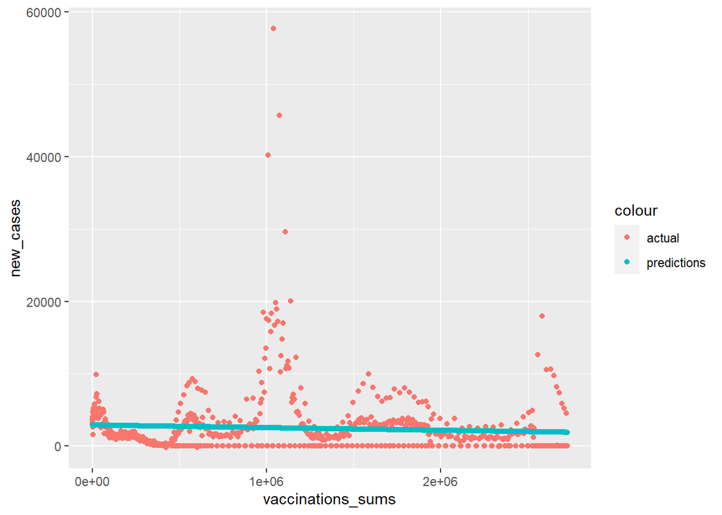

```
##
## Call:
## lm(formula = new_deaths ~ vaccinations_sums, data = virginia_totals_vaccination)
##
## Residuals:
##     Min      1Q  Median      3Q     Max
## -124.16  -19.96   -8.64    6.72  380.15
##
## Coefficients:
##                     Estimate Std. Error t value Pr(>|t|)
## (Intercept)        3.589e+01  2.307e+00  15.555  < 2e-16 ***
## vaccinations_sums -1.030e-05  1.580e-06  -6.519 1.24e-10 ***
## ---
## Signif. codes:  0 '***' 0.001 '**' 0.01 '*' 0.05 '.' 0.1 ' ' 1
##
## Residual standard error: 38.12 on 813 degrees of freedom
## Multiple R-squared:  0.04968,    Adjusted R-squared:  0.04851
## F-statistic:  42.5 on 1 and 813 DF,  p-value: 1.238e-10
```

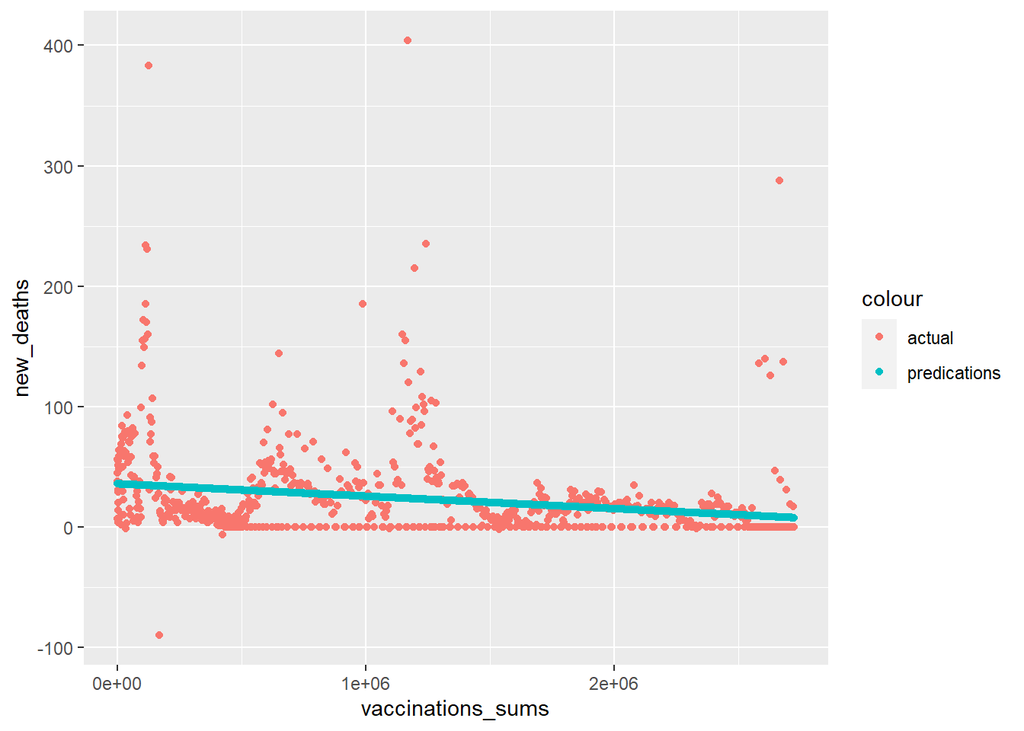

Now these models look wonky. There are huge outliers in the actual data. But, in both cases, we see the expected correlation where as the number of vaccinations given goes up, the number of new deaths and cases goes down. But the model still does not look great and seems to not fit the data as well. So I will take a deeper dive to try to figure out why this is happening. So let’s take a look at what’s happening for new_cases over time in depth.

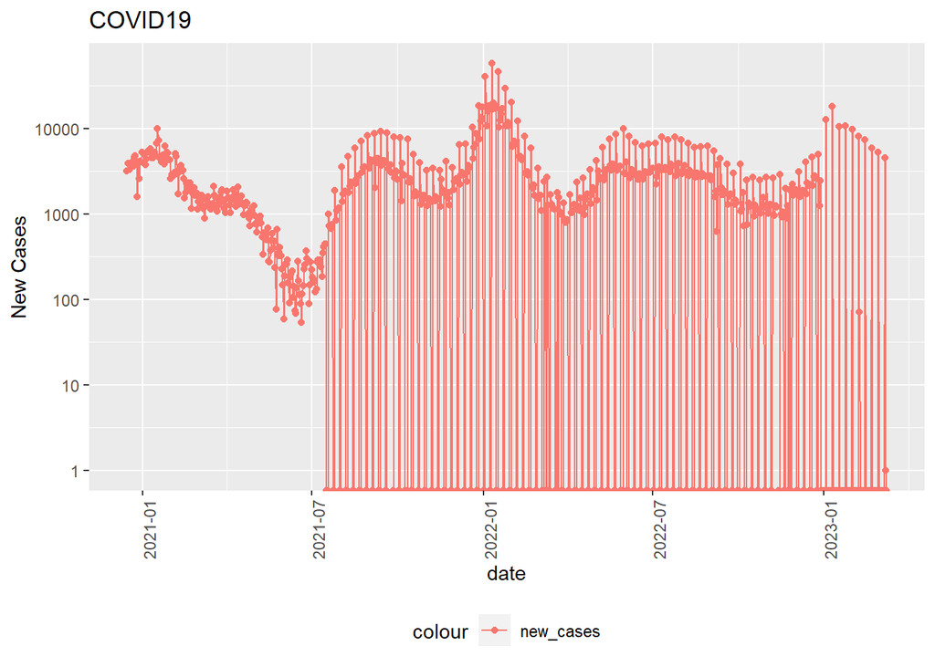

Wow. Something is definitely awry here. Up until about mid 2021, there was consistent decline in the number of cases and then there are these large fluctuations where the data drops down to zero and then shoots back up. Let’s take a look at that abnormal data. I will give you the same plot filtered by where the date > 07-01-2021.

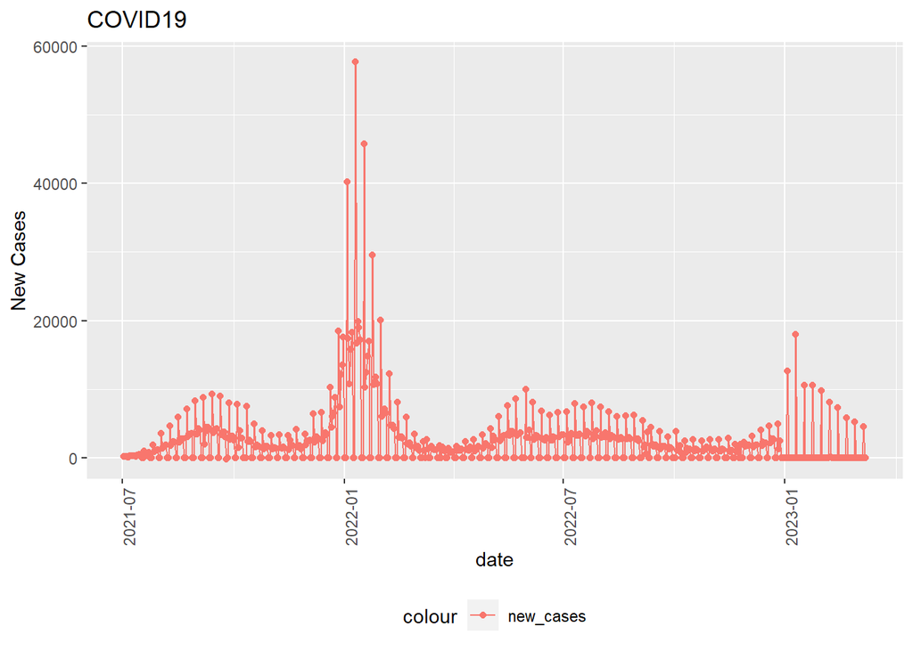

Ok we can see more clearly that something is clearly up. Let’s zoom in on a section and see if we can spot what’s happening. I’m going to filter the data again, this time by date > 01-01-2023.

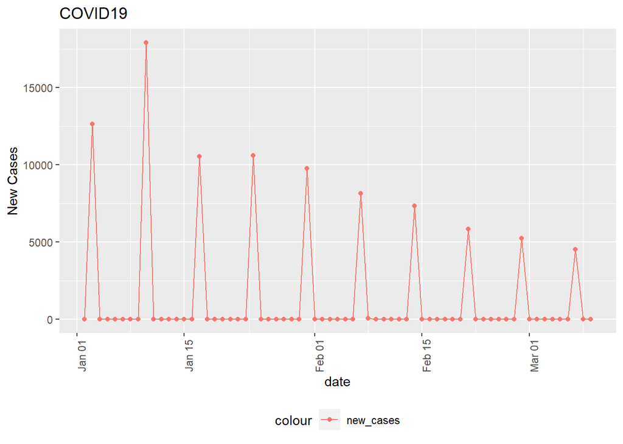

```r
virginia_totals_vaccination %>% filter(date > "2023-01-01") %>%
  ggplot(aes(x=date, y=new_cases)) +
  geom_line(aes(color = "new_cases")) +
  geom_point(aes(color = "new_cases")) +
  #scale_y_log10() +
  theme(legend.position = "bottom",
        axis.text.x = element_text(angle=90)) +
  labs(title = "COVID19", y="New Cases")
```

```
##
## Call:
## lm(formula = new_cases ~ vaccinations, data = virginia_totals_vaccination_modified)
##
## Residuals:
##     Min      1Q  Median      3Q     Max
## -3257.3 -1149.7   -46.8   769.5  6476.3
##
## Coefficients:
##               Estimate Std. Error t value Pr(>|t|)
## (Intercept)  3911.1144   281.3668  13.900  < 2e-16 ***
## vaccinations   -0.8849     0.1192  -7.425 3.38e-12 ***
## ---
## Signif. codes:  0 '***' 0.001 '**' 0.01 '*' 0.05 '.' 0.1 ' ' 1
##
## Residual standard error: 1581 on 196 degrees of freedom
## Multiple R-squared:  0.2195, Adjusted R-squared:  0.2155
## F-statistic: 55.13 on 1 and 196 DF,  p-value: 3.379e-12
```

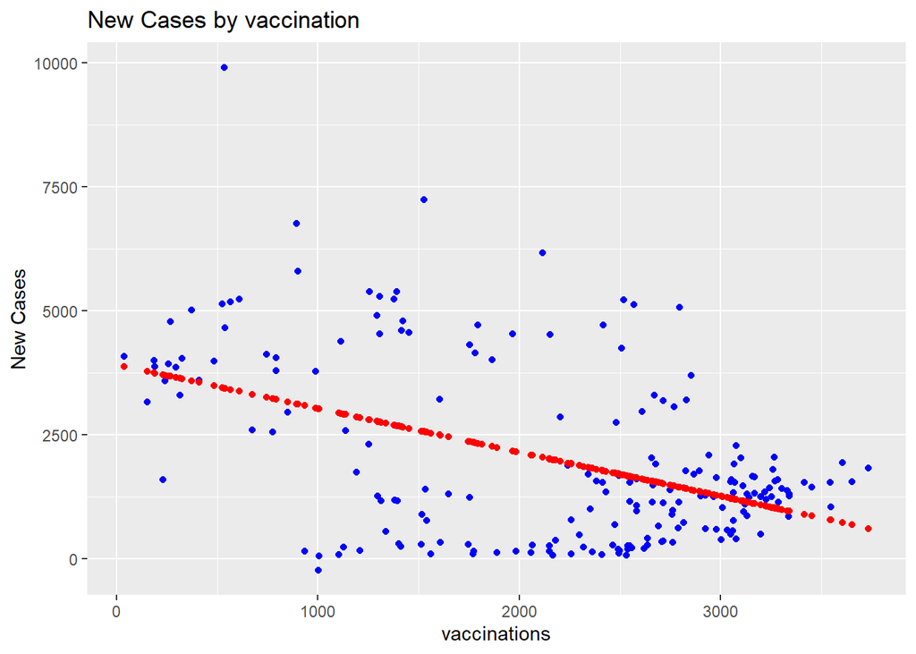

This is a much better model and has conclusions closer to what we would expect. I will skip doing the deaths, but a similar thing occurs in the new deaths where there appears to be some summations.

# Conclusions

So my main takeaways from this project:  
1. I leave it with more questions than I have answers. That is the case for most entry level analysis.  
2. Something that I learned early, “Never trust the data”. In my opinion, the way that the data was reported changed at some point. It went from daily checks to checks on an interval.This will definitely affect any daily analysis and it is important that this noted.

While we’re talking about data quality, we can also talk about bias. I worked previously in vaccine sciences, so I had preconceived thoughts about how I expected the data to look. But, the key to not letting your bias creep in is to let the data tell the story instead of you. When I saw something that didn’t look right, I continued to dig deeper and looked at what else the data was showing. Another thing that should be noted is bias in data reporting and taking in this case. COVID-19 was not always reported consistently. I know when I got COVID-19, I took an at home test, but did not feel the need to go to the doctor. There is no real record of cases like mine where the COVID-19 was not reported anywhere. So the numbers may be higher even then we thought.

The final conclusion is that, there is a lot more work to be done if we want to ever take a comprehensive look at COVID-19. But for now, i’ll end my project here.